# Lecture 6

Spatial point processes

Sara Martino

sara.martino@ntnu.no

Dept. of Mathematical Science, NTNU

Janine Illian

Janine.Illian@glasgow.ac.uk

University of Glasgow

Jafet Belmont

Jafet.Belmont@glasgow.ac.uk

University of Glasgow

# Spatial point processes

## Point process data

Many of the ecological and environmental processes of interest can be represented by a spatial point process or can be viewed as an aggregation of one.

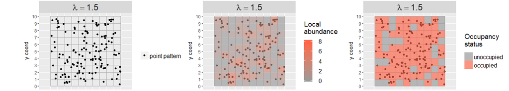

- Many contemporary data sources collect georeferenced information about the location where an event has occur (e.g., species occurrence, wildfire, flood events).
- This point-based information provides valuable insights into ecosystem dynamics.

## Point patterns vs. geostatistical data

**Point patterns:**

- Data format: x,y coordinates
- Optional: marks
- Aim: model locations as random

**Geostatistical data:**

- Data format: x,y coordinates
- Measurements mandatory
- Aim: model continuous process at fixed locations

**models of spatial patterns**: modelling locations and properties (*“marks”*) of objects, events, individuals in space and time

**aim**: understanding mechanisms that generated the pattern

## Defining a Point Process

- Consider a fixed geographical region $A$.
- The set of locations at which events occur are denoted by $\mathbf{s} = (\mathbf{s}_1, \ldots, \mathbf{s}_n)$.
- We let $N(A)$ be a random variable which represents the total number of events in every subset of region $A$.
- Our primary interest is in measuring where events occur, so the **locations are our data**.
- Let $\lambda$ the *intensity* or *point density*, i.e, the mean number of points per unit area
- In some cases, the intensity will be constant over space (homogeneous), while in other cases it can vary by location (inhomogeneous).
- If our intensity is homogeneous, we can define it as

  $$\lambda(s) = \frac{\mathbb{E}[N(A)]}{|A|} = \frac{\lambda |A|}{|A|} = \lambda.$$

## Complete spatial randomness

We can use the concept of intensity to help us define **complete spatial randomness (CSR)**.

- For any spatial region $A$, CSR requires that:
1. *Uniformity and Independent scattering* : Given the number of events $N(A) = n$ in a region, the $n$ events are independently and have an equal probability of occurring anywhere in the study area.
2. *Poisson distribution of point counts*: The number of points in any set $A_i$ follows a Poisson distribution with mean $\lambda|A_i|$, that is
   $$N(A_i) \sim \text{Poisson}(\lambda \,|A_i|).$$
- If these conditions are satisfied, we can describe our process as a **homogeneous Poisson process**.

## Homogeneous Poisson Process

- A simplest point process model is the homogeneous Poisson process (HPP).
- The likelihood of a point pattern $\mathbf{y} = \left[ \mathbf{s}_1, \ldots, \mathbf{s}_n \right]^\intercal$ distributed as a HPP with intensity $\lambda$ and observation window $\Omega$ is

  $$p(\mathbf{y} | \lambda) \propto \lambda^n e^{ \left( - |\Omega| \lambda \right)} ,$$
  - $|\Omega|$ is the size of the observation window.
  - $\lambda$ is the expected number of points per unit area.
  - $|\Omega|\lambda$ the total expected number of points in the observation window.
- A key property of a Poisson process is that the number of points within any subset $A_i$ of region $A$ is Poisson distributed with constant rate $|A_i|\lambda$.

## Inhomogeneous Poisson process

Let $\mathbf{y} = s_1,\ldots,s_n$ the $n$ number of observed events/points in an observation window $\Omega$

For an IPP with an intensity $\lambda(s)$, the likelihood is given by:

$$p(\mathbf{y} | \lambda) \propto \exp \left( -\int_\Omega \lambda(\mathbf{s}) \mathrm{d}\mathbf{s} \right) \prod_{i=1}^n \lambda(\mathbf{s}_i).$$

- If the case of an **HPP** the integral in the likelihood can easily be computed as $\int_\Omega \lambda(\mathbf{s}) \mathrm{d}\mathbf{s} =|\Omega|\lambda$
- For an **HPP** with an intensity $\lambda$, the log-likelihood is given by:
  $$l(\beta;\mathbf{y}) = n\log(\lambda) -\lambda|\Omega|,$$
- The maximum likelihood estimators is $\hat{\lambda} = n/|\Omega|$.
- For **IPP**, the integral in the likelihood has to be approximateda as a weighted sum.

## Inhomogeneous Poisson process

This integral is approximated as $\int_\Omega \lambda(\mathbf{s}) \mathrm{d}\mathbf{s} \approx \sum_{j=1}^J w_j \lambda(\mathbf{s}_j)$

- $w_j$ are the integration weights
- $\mathbf{s}_j$ are the quadrature locations.

This serves two purposes:

1. Approximating the integral
2. re-writing the inhomogeneous Poisson process likelihood as a regular Poisson likelihood.

## Inhomogeneous Poisson process

The idea behind the trick to rewrite the approximate likelihood is to introduce a dummy vector $\mathbf{z}$ and an integration weights vector $\mathbf{w}$ of length $J + n$

$$\mathbf{z} = \left[\underbrace{0_1, \ldots,0_J}_\text{quadrature locations}, \underbrace{1_1, \ldots ,1_n}_{\text{data points}} \right]^\intercal$$

$$\mathbf{w} = \left[ \underbrace{w_1, \ldots, w_J}_\text{quadrature locations}, \underbrace{0_1, \ldots, 0_n}_\text{data points} \right]^\intercal$$

Then the approximate likelihood can be written as

$$\begin{aligned}
p(\mathbf{z} | \lambda) &\propto \prod_{i=1}^{J + n} \eta_i^{z_i} \exp\left(-w_i \eta_i \right) \\
\eta_i &= \log\lambda(\mathbf{s}_i) = \mathbf{x}(s)'\beta
\end{aligned}$$

- This is similar to a product of Poisson distributions with means $\eta_i$, exposures $w_i$ and observations $z_i$

## Limitations with IPP

- IPP models assume that data points are conditionally independent given the covariates, meaning that any spatial variation is fully explained by environmental and sampling factors.
- Unmeasured endogenous and exogenous factors can create spatial dependence.
- Ignoring them can lead to bias in our conclusions.

## The Log-Gaussian Cox Process

- Log-Gaussian Cox processes (LGCP) extend the IPP by allowing the intensity function to vary spatially according to a structured spatial random effect, i.e. the intensity is random

$$\log~\lambda(s)= \mathbf{x}(s)'\beta + \xi(s)$$

- The events are then assumed to be independent given the covariates and $\xi(s)$ - a GRF with Matérn covariance.

How do we model $\xi(s)$ ?

- We use an SPDE model!
- The software `inlabru` has implemented some integration schemes that are especially well suited to integrating the intensity in models with an SPDE effect.
- By default, `inlabru` uses the same points to define the SPDE approximation and to approximate the integral in the likelihood, but this can be changed.

See for further reference: Simpson, Daniel, Janine B. Illian, Finn Lindgren, Sigrunn H. Sørbye, and Håvard Rue. 2016. “Going off grid: computationally efficient inference for log-Gaussian Cox processes.” *Biometrika* 103 (1): 49–70.

# Example: Forest fires

## Example: Forest fires in Castilla-La Mancha

- In this example we model the location of forest fires in the Castilla-La Mancha region of Spain between 1998 and 2007.
- We are now going to use the elevation as a covariate to explain the variability of the intensity $\lambda(s)$ over the domain of interest and a spatially structured SPDE model.

$$\log\lambda(s) = \beta_0 + \beta_1 \text{elevation}(s) + \xi(s)$$

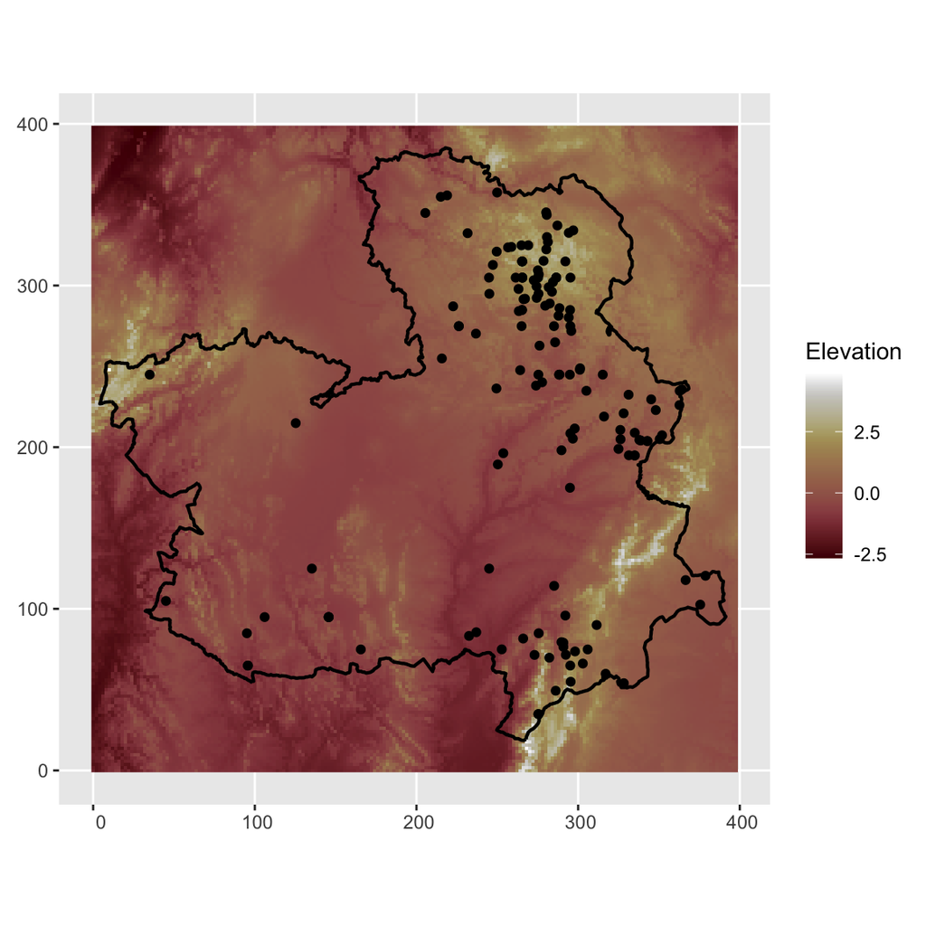

```r
pp  %>% print(n = 6)
```

```
Simple feature collection with 148 features and 4 fields
Geometry type: POINT
Dimension:     XY
Bounding box:  xmin: 34.96293 ymin: 34.87499 xmax: 378.819 ymax: 357.528
CRS:           NA
First 6 features:
      cause burnt.area       date julian.date                  geometry
1 lightning       0.01 2004-01-08        2198 POINT (165.5546 74.87501)
2 lightning       0.04 2004-01-08        2198  POINT (215.7145 254.875)
3 lightning       0.80 2004-01-08        2198   POINT (263.326 284.166)
4 lightning       0.00 2004-01-08        2198  POINT (265.2747 284.875)
5 lightning       0.25 2004-01-08        2198   POINT (236.799 270.223)
6 lightning       0.01 2004-01-09        2199   POINT (297.892 211.545)
```

## Example: Forest fires in Castilla-La Mancha

**The IPP Model**
$$\begin{aligned}
p(\mathbf{y} | \lambda) & \propto \exp \left( -\int_\Omega \lambda(\mathbf{s}) \mathrm{d}\mathbf{s} \right) \prod_{i=1}^n \lambda(\mathbf{s}_i) \\
\eta(s) & = \log ~\lambda(s) = \beta_0 + \beta_1 \,x(s)
\end{aligned}$$
**The code**

```r
# define model component
cmp = ~ Intercept(1) + elev(elev_raster, model = "linear")

# define model predictor
eta  = geometry ~ Intercept +  elev

# build the observation model
lik = bru_obs("cp",
              formula = eta,
              data = pp,
              ips = ips)

# fit the model
fit = bru(cmp, lik)
```

- Regular Grid
- `fm_int`

```r
n.int = 1000
ips <- st_sample(region, size = n.int, type = "regular") # May not be exactly n.int points
ips <- new_fm_int(
  ips,
  weight = st_area(region) / length(ips),
  name = "geometry"
)
```

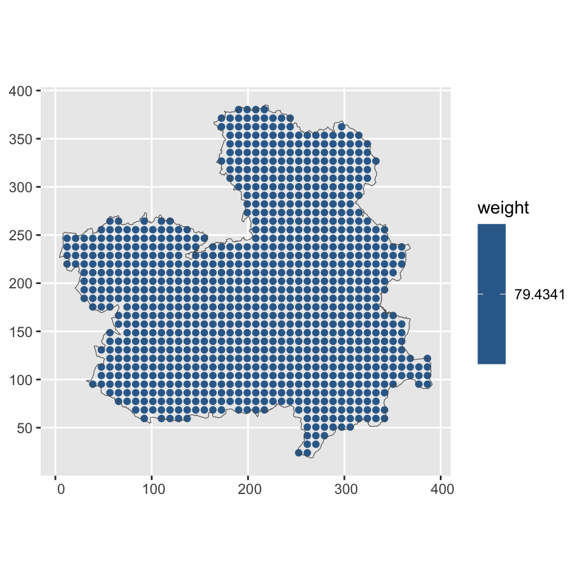

```r
# The mesh
mesh = fm_mesh_2d(boundary = region,
                  max.edge = c(5, 10),
                  cutoff = 4, crs = NA)

# build integration scheme
ips = fm_int(mesh,
             samplers = region)
```

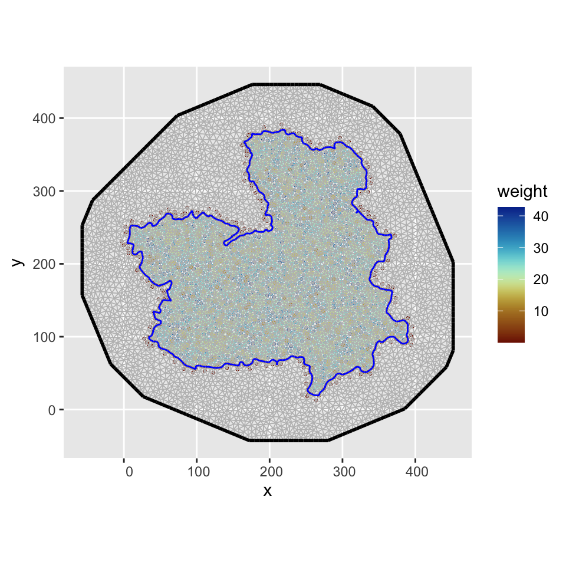

## Example: Forest fires in Castilla-La Mancha

**The LGCP Model**

$$\begin{aligned}
p(\mathbf{y} | \lambda) & \propto \exp \left( -\int_\Omega \lambda(\mathbf{s}) \mathrm{d}\mathbf{s} \right) \prod_{i=1}^n \lambda(\mathbf{s}_i) \\
\eta(s) & = \log(\lambda(s)) = \color{#FF6B6B}{\boxed{\beta_0}} + \color{#FF6B6B}{\boxed{\beta_1 x(s)}} + \color{#FF6B6B}{\boxed{ \omega(s)}}\\
\end{aligned}$$

**The code**

```r
# define model component
cmp = ~ Intercept(1) + elev(elev_raster, model = "linear") +
  space(geometry, model = spde_model)


# define model predictor
eta  = geometry ~ Intercept +  elev + space


# build the observation model
lik = bru_obs("cp",
              formula = eta,
              data = pp,
              ips = ips)


# fit the model
fit = bru(cmp, lik)
```

```r
# The mesh
mesh = fm_mesh_2d(boundary = region,
                  max.edge = c(5, 10),
                  cutoff = 4, crs = NA)

# The SPDE model
spde_model =  inla.spde2.pcmatern(mesh,
                                  prior.sigma = c(1, 0.5),
                                  prior.range = c(100, 0.5))

# build integration scheme
ips = fm_int(mesh,
             samplers = region)
```

## Example: Forest fires in Castilla-La Mancha

**The LGCP Model**

$$\begin{aligned}
p(\mathbf{y} | \lambda) & \propto \exp \left( -\int_\Omega \lambda(\mathbf{s}) \mathrm{d}\mathbf{s} \right) \prod_{i=1}^n \lambda(\mathbf{s}_i) \\
\color{#FF6B6B}{\boxed{\eta(s)}} & = \log(\lambda(s)) = \color{#FF6B6B}{\boxed{\beta_0 + \beta_1 x(s) + \omega(s)}}\\
\end{aligned}$$

**The code**

```r
# define model component
cmp = ~ Intercept(1) + elev(elev_raster, model = "linear") +
  space(geometry, model = spde_model)


# define model predictor
eta  = geometry ~ Intercept +  elev + space


# build the observation model
lik = bru_obs("cp",
              formula = eta,
              data = pp,
              ips = ips)


# fit the model
fit = bru(cmp, lik)
```

```r
# The mesh
mesh = fm_mesh_2d(boundary = region,
                  max.edge = c(5, 10),
                  cutoff = 4, crs = NA)

# The SPDE model
spde_model =  inla.spde2.pcmatern(mesh,
                                  prior.sigma = c(1, 0.5),
                                  prior.range = c(100, 0.5))

# build integration scheme
ips = fm_int(mesh,
             samplers = region)
```

## Example: Forest fires in Castilla-La Mancha

**The LGCP Model**

$$\begin{aligned}
\color{#FF6B6B}{\boxed{p(\mathbf{y} | \lambda)}} & \propto \exp \left( -\int_\Omega \lambda(\mathbf{s}) \mathrm{d}\mathbf{s} \right) \prod_{i=1}^n \lambda(\mathbf{s}_i) \\
\eta(s) & = \log(\lambda(s)) = \beta_0 + \beta_1x(s) + \omega(s)\\
\end{aligned}$$

**The code**

```r
# define model component
cmp = ~ Intercept(1) + elev(elev_raster, model = "linear") +
  space(geometry, model = spde_model)


# define model predictor
eta  = geometry ~ Intercept +  elev + space


# build the observation model
lik = bru_obs("cp",
              formula = eta,
              data = pp,
              ips = ips)


# fit the model
fit = bru(cmp, lik)
```

```r
# The mesh
mesh = fm_mesh_2d(boundary = region,
                  max.edge = c(5, 10),
                  cutoff = 4, crs = NA)

# The SPDE model
spde_model =  inla.spde2.pcmatern(mesh,
                                  prior.sigma = c(1, 0.5),
                                  prior.range = c(100, 0.5))

# build integration scheme
ips = fm_int(mesh,
             samplers = region)
```

## Example: Forest fires in Castilla-La Mancha

**The LGCP Model**

$$\begin{aligned}
p(\mathbf{y} | \lambda) & \propto \exp \left( -\int_\Omega \lambda(\mathbf{s}) \mathrm{d}\mathbf{s} \right) \prod_{i=1}^n \lambda(\mathbf{s}_i) \\
\eta(s) & = \log(\lambda(s)) = \beta_0 + \beta_1 x(s) + \omega(s)\\
\end{aligned}$$

**The code**

```r
# define model component
cmp = ~ Intercept(1) + elev(elev_raster, model = "linear") +
  space(geometry, model = spde_model)


# define model predictor
eta  = geometry ~ Intercept +  elev + space


# build the observation model
lik = bru_obs("cp",
              formula = eta,
              data = pp,
              ips = ips)


# fit the model
fit = bru(cmp, lik)
```

```r
# The mesh
mesh = fm_mesh_2d(boundary = region,
                  max.edge = c(5, 10),
                  cutoff = 4, crs = NA)

# The SPDE model
spde_model =  inla.spde2.pcmatern(mesh,
                                  prior.sigma = c(1, 0.5),
                                  prior.range = c(100, 0.5))

# build integration scheme
ips = fm_int(mesh,
             samplers = region)
```

## Example: Forest fires in Castilla-La Mancha

**Model Predictions**

We can use the `predict()` method to visualize the posterior mean intensity, log-intensity, std dev, and the SPDE.

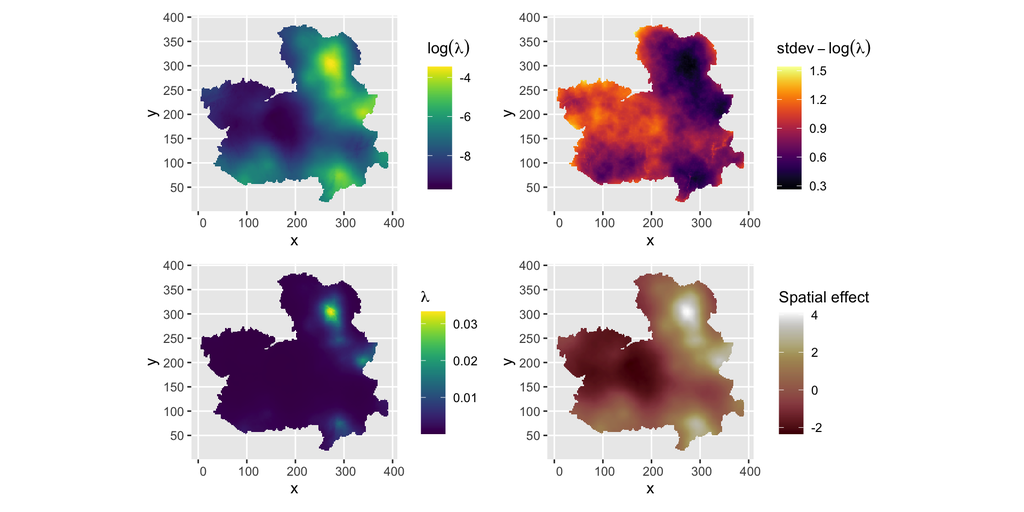

**Note**

Note that the mean field is, by definition, smoother than any realization of the field. Instead we can draw simulations of the field from the posterior distribution using the `generate()` function.

## Posterior quantities

We can estimate the total number of events over the whole region as follows:

$$\mathbb{E}(N_\Omega) = \int_\Omega \exp(\lambda(s)) ds$$

To do so, we simulate possible realizations of $N_\omega$ to include also the likelihood variability in our estimate using the `generate()` method

```r
N_fires = generate(fit, ips,
                      formula = ~ {
                        lambda = sum(weight * exp(elev + Intercept + space))
                        rpois(1, lambda)},
                    n.samples = 2000)
```

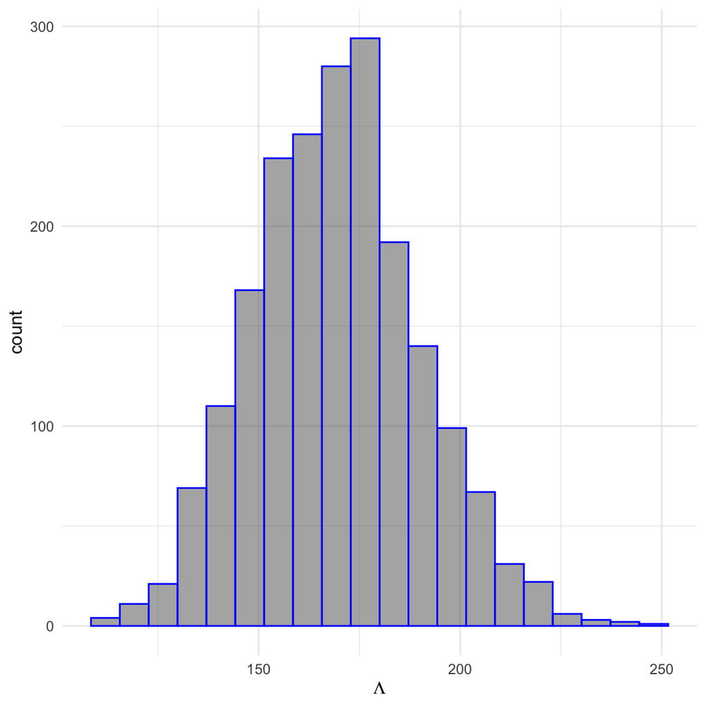

## Take-home messages

- Point processes are a stochastic processes that describe the locations where events occur
- Unlike geostatistical data where the locations are fixed, here the locations have a stochastic nature; *the locations are our data*!
- IPPs allow the intensity of the point process to vary across space through spatially varying covariates.
- Numerical integration schemes are required to estimate the parameters of an IPP
- LGCP are a doubly stochastic process that extends IPP models by allowing the intensity function to vary spatially according to a structured spatial random effect

# References

Laxton, Megan R, Óscar Rodrı́guez de Rivera, Andrea Soriano-Redondo, and Janine B Illian. 2023. “Balancing Structural Complexity with Ecological Insight in Spatio-Temporal Species Distribution Models.” *Methods in Ecology and Evolution* 14 (1): 162–72.

Palmı́-Perales, Francisco, Finn Lindgren, and Virgilio Gómez-Rubio. 2025. “Bayesian Inference for Case-Control Point Pattern Data in Spatial Epidemiology with the Inlabru r Package.” *arXiv Preprint arXiv:2503.14954*.

Rivera, Óscar Rodrı́guez de, Juncal Espinosa, Javier Madrigal, Marta Blangiardo, and Antonio López-Quı́lez. 2025. “Spatio-Temporal Marked Point Process Model to Understand Forest Fires in the Mediterranean Basin: Ór d. Rivera Et Al.” *Journal of Agricultural, Biological and Environmental Statistics* 30 (3): 700–729.

Simpson, Daniel, Janine Baerbel Illian, Finn Lindgren, Sigrunn H Sørbye, and Havard Rue. 2016. “Going Off Grid: Computationally Efficient Inference for Log-Gaussian Cox Processes.” *Biometrika* 103 (1): 49–70.